# Practical Machine Learning Course Project

### Executive Summary

The goal of this project was to use data from accelerometers on the belt, forearm, arm and dumbell of 6 people. Each of them performed an exercise correctly and incorrectly 5 different ways. In the end, I wanted to find out the manner in which they did the exercise which is represented by the “classe” variable in the training set.

### Data Sources

1. https://d396qusza40orc.cloudfront.net/predmachlearn/pml-training.csv
2. https://d396qusza40orc.cloudfront.net/predmachlearn/pml-testing.csv
3. http://groupware.les.inf.puc-rio.br/har

### Data Preparation

For the data preparation I loaded the training and testing data set into R and then saw the structure of the data. I then took out the indices which indicated the columns to remove in the updated training and testing set. I chose the column indices where it was either blank space or had 95% NA’s in the data. I also then removed columns 1-7 and partitioned the training and testing set. I created 80% training data and 20% testing data. For the test set, I removed the partitioned training data to later test it later on.

```r
#Check current working directory
getwd()
```

```
## [1] "/Users/andrew.delos.santos/Desktop"
```

```r
#Load needed packages and libraries
library(readr)
#Load the data into R using read_csv
training_data_url <- "https://d396qusza40orc.cloudfront.net/predmachlearn/pml-training.csv"
testing_data_url <- "https://d396qusza40orc.cloudfront.net/predmachlearn/pml-testing.csv"
#Read in the csv files using read_csv which takes care of dates and
#url file connections
training <- read_csv(training_data_url)
testing <- read_csv(testing_data_url)
#See the column names, first 6 rows of data, dimension, and structure
colnames(training)
```

```
##   [1] "X1"                       "user_name"
##   [3] "raw_timestamp_part_1"     "raw_timestamp_part_2"
##   [5] "cvtd_timestamp"           "new_window"
##   [7] "num_window"               "roll_belt"
##   [9] "pitch_belt"               "yaw_belt"
##  [11] "total_accel_belt"         "kurtosis_roll_belt"
##  [13] "kurtosis_picth_belt"      "kurtosis_yaw_belt"
##  [15] "skewness_roll_belt"       "skewness_roll_belt.1"
##  [17] "skewness_yaw_belt"        "max_roll_belt"
##  [19] "max_picth_belt"           "max_yaw_belt"
##  [21] "min_roll_belt"            "min_pitch_belt"
##  [23] "min_yaw_belt"             "amplitude_roll_belt"
##  [25] "amplitude_pitch_belt"     "amplitude_yaw_belt"
##  [27] "var_total_accel_belt"     "avg_roll_belt"
##  [29] "stddev_roll_belt"         "var_roll_belt"
```

[output cut: 65 more lines]

```r
head(training)
```

```
## # A tibble: 6 x 160
##      X1 user_name raw_timestamp_p… raw_timestamp_p… cvtd_timestamp
##   <dbl> <chr>                <dbl>            <dbl> <chr>
## 1     1 carlitos        1323084231           788290 05/12/2011 11…
## 2     2 carlitos        1323084231           808298 05/12/2011 11…
## 3     3 carlitos        1323084231           820366 05/12/2011 11…
## 4     4 carlitos        1323084232           120339 05/12/2011 11…
## 5     5 carlitos        1323084232           196328 05/12/2011 11…
## 6     6 carlitos        1323084232           304277 05/12/2011 11…
## # … with 155 more variables: new_window <chr>, num_window <dbl>,
## #   roll_belt <dbl>, pitch_belt <dbl>, yaw_belt <dbl>,
## #   total_accel_belt <dbl>, kurtosis_roll_belt <chr>,
## #   kurtosis_picth_belt <chr>, kurtosis_yaw_belt <chr>,
## #   skewness_roll_belt <chr>, skewness_roll_belt.1 <chr>,
## #   skewness_yaw_belt <chr>, max_roll_belt <dbl>, max_picth_belt <dbl>,
## #   max_yaw_belt <chr>, min_roll_belt <dbl>, min_pitch_belt <dbl>,
## #   min_yaw_belt <chr>, amplitude_roll_belt <dbl>,
## #   amplitude_pitch_belt <dbl>, amplitude_yaw_belt <chr>,
## #   var_total_accel_belt <dbl>, avg_roll_belt <dbl>,
## #   stddev_roll_belt <dbl>, var_roll_belt <dbl>, avg_pitch_belt <dbl>,
## #   stddev_pitch_belt <dbl>, var_pitch_belt <dbl>, avg_yaw_belt <dbl>,
## #   stddev_yaw_belt <dbl>, var_yaw_belt <dbl>, gyros_belt_x <dbl>,
## #   gyros_belt_y <dbl>, gyros_belt_z <dbl>, accel_belt_x <dbl>,
## #   accel_belt_y <dbl>, accel_belt_z <dbl>, magnet_belt_x <dbl>,
## #   magnet_belt_y <dbl>, magnet_belt_z <dbl>, roll_arm <dbl>,
## #   pitch_arm <dbl>, yaw_arm <dbl>, total_accel_arm <dbl>,
## #   var_accel_arm <dbl>, avg_roll_arm <dbl>, stddev_roll_arm <dbl>,
## #   var_roll_arm <dbl>, avg_pitch_arm <dbl>, stddev_pitch_arm <dbl>,
## #   var_pitch_arm <dbl>, avg_yaw_arm <dbl>, stddev_yaw_arm <dbl>,
## #   var_yaw_arm <dbl>, gyros_arm_x <dbl>, gyros_arm_y <dbl>,
## #   gyros_arm_z <dbl>, accel_arm_x <dbl>, accel_arm_y <dbl>,
## #   accel_arm_z <dbl>, magnet_arm_x <dbl>, magnet_arm_y <dbl>,
## #   magnet_arm_z <dbl>, kurtosis_roll_arm <dbl>, kurtosis_picth_arm <chr>,
## #   kurtosis_yaw_arm <chr>, skewness_roll_arm <dbl>,
## #   skewness_pitch_arm <chr>, skewness_yaw_arm <chr>, max_roll_arm <dbl>,
## #   max_picth_arm <dbl>, max_yaw_arm <dbl>, min_roll_arm <dbl>,
## #   min_pitch_arm <dbl>, min_yaw_arm <dbl>, amplitude_roll_arm <dbl>,
## #   amplitude_pitch_arm <dbl>, amplitude_yaw_arm <dbl>,
## #   roll_dumbbell <dbl>, pitch_dumbbell <dbl>, yaw_dumbbell <dbl>,
## #   kurtosis_roll_dumbbell <dbl>, kurtosis_picth_dumbbell <dbl>,
## #   kurtosis_yaw_dumbbell <chr>, skewness_roll_dumbbell <dbl>,
## #   skewness_pitch_dumbbell <dbl>, skewness_yaw_dumbbell <chr>,
## #   max_roll_dumbbell <dbl>, max_picth_dumbbell <dbl>,
## #   max_yaw_dumbbell <dbl>, min_roll_dumbbell <dbl>,
## #   min_pitch_dumbbell <dbl>, min_yaw_dumbbell <dbl>,
## #   amplitude_roll_dumbbell <dbl>, amplitude_pitch_dumbbell <dbl>,
## #   amplitude_yaw_dumbbell <dbl>, total_accel_dumbbell <dbl>,
## #   var_accel_dumbbell <dbl>, avg_roll_dumbbell <dbl>,
## #   stddev_roll_dumbbell <dbl>, …
```

```r
dim(training)
```

```
## [1] 19622   160
```

```r
str(training)
```

[output not shown]

[output cut: 215 more lines]

[output not shown]

```r
colnames(testing)
```

```
##   [1] "X1"                       "user_name"
##   [3] "raw_timestamp_part_1"     "raw_timestamp_part_2"
##   [5] "cvtd_timestamp"           "new_window"
##   [7] "num_window"               "roll_belt"
##   [9] "pitch_belt"               "yaw_belt"
##  [11] "total_accel_belt"         "kurtosis_roll_belt"
##  [13] "kurtosis_picth_belt"      "kurtosis_yaw_belt"
##  [15] "skewness_roll_belt"       "skewness_roll_belt.1"
##  [17] "skewness_yaw_belt"        "max_roll_belt"
##  [19] "max_picth_belt"           "max_yaw_belt"
##  [21] "min_roll_belt"            "min_pitch_belt"
##  [23] "min_yaw_belt"             "amplitude_roll_belt"
##  [25] "amplitude_pitch_belt"     "amplitude_yaw_belt"
##  [27] "var_total_accel_belt"     "avg_roll_belt"
##  [29] "stddev_roll_belt"         "var_roll_belt"
```

[output cut: 65 more lines]

```r
head(testing)
```

```
## # A tibble: 6 x 160
##      X1 user_name raw_timestamp_p… raw_timestamp_p… cvtd_timestamp
##   <dbl> <chr>                <dbl>            <dbl> <chr>
## 1     1 pedro           1323095002           868349 05/12/2011 14…
## 2     2 jeremy          1322673067           778725 30/11/2011 17…
## 3     3 jeremy          1322673075           342967 30/11/2011 17…
## 4     4 adelmo          1322832789           560311 02/12/2011 13…
## 5     5 eurico          1322489635           814776 28/11/2011 14…
## 6     6 jeremy          1322673149           510661 30/11/2011 17…
## # … with 155 more variables: new_window <chr>, num_window <dbl>,
## #   roll_belt <dbl>, pitch_belt <dbl>, yaw_belt <dbl>,
## #   total_accel_belt <dbl>, kurtosis_roll_belt <lgl>,
## #   kurtosis_picth_belt <lgl>, kurtosis_yaw_belt <lgl>,
## #   skewness_roll_belt <lgl>, skewness_roll_belt.1 <lgl>,
## #   skewness_yaw_belt <lgl>, max_roll_belt <lgl>, max_picth_belt <lgl>,
## #   max_yaw_belt <lgl>, min_roll_belt <lgl>, min_pitch_belt <lgl>,
## #   min_yaw_belt <lgl>, amplitude_roll_belt <lgl>,
## #   amplitude_pitch_belt <lgl>, amplitude_yaw_belt <lgl>,
## #   var_total_accel_belt <lgl>, avg_roll_belt <lgl>,
## #   stddev_roll_belt <lgl>, var_roll_belt <lgl>, avg_pitch_belt <lgl>,
## #   stddev_pitch_belt <lgl>, var_pitch_belt <lgl>, avg_yaw_belt <lgl>,
## #   stddev_yaw_belt <lgl>, var_yaw_belt <lgl>, gyros_belt_x <dbl>,
## #   gyros_belt_y <dbl>, gyros_belt_z <dbl>, accel_belt_x <dbl>,
## #   accel_belt_y <dbl>, accel_belt_z <dbl>, magnet_belt_x <dbl>,
## #   magnet_belt_y <dbl>, magnet_belt_z <dbl>, roll_arm <dbl>,
## #   pitch_arm <dbl>, yaw_arm <dbl>, total_accel_arm <dbl>,
## #   var_accel_arm <lgl>, avg_roll_arm <lgl>, stddev_roll_arm <lgl>,
## #   var_roll_arm <lgl>, avg_pitch_arm <lgl>, stddev_pitch_arm <lgl>,
## #   var_pitch_arm <lgl>, avg_yaw_arm <lgl>, stddev_yaw_arm <lgl>,
## #   var_yaw_arm <lgl>, gyros_arm_x <dbl>, gyros_arm_y <dbl>,
## #   gyros_arm_z <dbl>, accel_arm_x <dbl>, accel_arm_y <dbl>,
## #   accel_arm_z <dbl>, magnet_arm_x <dbl>, magnet_arm_y <dbl>,
## #   magnet_arm_z <dbl>, kurtosis_roll_arm <lgl>, kurtosis_picth_arm <lgl>,
## #   kurtosis_yaw_arm <lgl>, skewness_roll_arm <lgl>,
## #   skewness_pitch_arm <lgl>, skewness_yaw_arm <lgl>, max_roll_arm <lgl>,
## #   max_picth_arm <lgl>, max_yaw_arm <lgl>, min_roll_arm <lgl>,
## #   min_pitch_arm <lgl>, min_yaw_arm <lgl>, amplitude_roll_arm <lgl>,
## #   amplitude_pitch_arm <lgl>, amplitude_yaw_arm <lgl>,
## #   roll_dumbbell <dbl>, pitch_dumbbell <dbl>, yaw_dumbbell <dbl>,
## #   kurtosis_roll_dumbbell <lgl>, kurtosis_picth_dumbbell <lgl>,
## #   kurtosis_yaw_dumbbell <lgl>, skewness_roll_dumbbell <lgl>,
## #   skewness_pitch_dumbbell <lgl>, skewness_yaw_dumbbell <lgl>,
## #   max_roll_dumbbell <lgl>, max_picth_dumbbell <lgl>,
## #   max_yaw_dumbbell <lgl>, min_roll_dumbbell <lgl>,
## #   min_pitch_dumbbell <lgl>, min_yaw_dumbbell <lgl>,
## #   amplitude_roll_dumbbell <lgl>, amplitude_pitch_dumbbell <lgl>,
## #   amplitude_yaw_dumbbell <lgl>, total_accel_dumbbell <dbl>,
## #   var_accel_dumbbell <lgl>, avg_roll_dumbbell <lgl>,
## #   stddev_roll_dumbbell <lgl>, …
```

```r
dim(testing)
```

```
## [1]  20 160
```

```r
str(testing)
```

[output not shown]

[output cut: 209 more lines]

[output not shown]

```r
#Clean the training set and get rid of the NA columns that have at least
#95% na values
x_training <- which(colSums(is.na(training) | training == "") > 0.95*dim(training)[1])
x_training_updated <- training[,-x_training]
x_training_updated <- x_training_updated[,-c(1:7)]
dim(x_training_updated)
```

```
## [1] 19622    53
```

```r
#Clean the test set like the previous example
x_test <- which(colSums(is.na(testing) | testing == "") > 0.95*dim(testing)[1])
x_test_updated <- testing[,-x_test]
x_test_updated <- x_test_updated[,-1]
dim(x_test_updated)
```

```
## [1] 20 59
```

```r
#Attempt classification method here
library(caret)
library(rpart)
library(rattle)
```

```r
library(rpart.plot)
library(RColorBrewer)
library(randomForest)
library(e1071)
library(mlbench)
#Partition training set. Using 80% training and 20% testing
#Set the seed for reproducibility
set.seed(1)
#Create training partitioned data
training_partitioned <- createDataPartition(x_training_updated[["classe"]], p = 0.80, list = FALSE)
#Create training and test set and check the dimensions
Train <- x_training_updated[training_partitioned, ]
Test <- x_training_updated[-training_partitioned,]
dim(Train)
```

```
## [1] 15699    53
```

```r
dim(Test)
```

```
## [1] 3923   53
```

### Classification Tree Method

I first decided to implement a classification tree to see if it was accurate to test the predictors. I used a cross validation method that had 10 folds in order to truly increase the accuracy and so called “folds” to divide the data to implement training. Cross validation is one of the most popular approaches when creating the training set. However, as the model was built with the variables under the names, the accuracy of the model was not too good at only about a 49% level. I then decided to try a random forest approach.

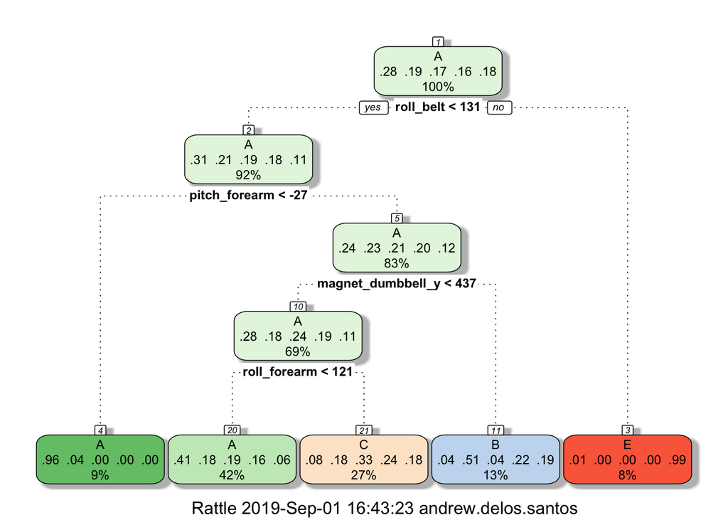

```r
#Attempt classification method here
library(caret)
library(rpart)
library(rattle)
library(rpart.plot)
library(RColorBrewer)
library(randomForest)
library(e1071)
library(mlbench)
#Specify the method for trainControl. Use cross validated method
#with 10 folds to increase accuracy when testing the data
train_control <- trainControl(method = "cv", number = 10)
#Set the seed again for reprocubility and use decision tree
set.seed(1)
tree_model <- train(classe~., data = Train, method = "rpart", trControl = train_control)
#See the plot
fancyRpartPlot(tree_model[["finalModel"]])
```

```r
#Use the classification tree on the test set
train_predicted_model <- predict(tree_model, newdata = Test)
#View the information and overall results
conf_matrix <- confusionMatrix(table(Test[["classe"]],train_predicted_model))
#Create the overall confusion matrix and check the accuracy
conf_matrix
```

```
## Confusion Matrix and Statistics
##
##    train_predicted_model
##        A    B    C    D    E
##   A 1024   14   75    0    3
##   B  336  243  180    0    0
##   C  319   21  344    0    0
##   D  313  119  211    0    0
##   E  119  108  176    0  318
##
## Overall Statistics
##
##                Accuracy : 0.4917
##                  95% CI : (0.476, 0.5075)
##     No Information Rate : 0.5381
##     P-Value [Acc > NIR] : 1
##
##                   Kappa : 0.334
##
##  Mcnemar's Test P-Value : NA
##
## Statistics by Class:
##
##                      Class: A Class: B Class: C Class: D Class: E
## Sensitivity            0.4851  0.48119  0.34888       NA  0.99065
## Specificity            0.9492  0.84903  0.88424   0.8361  0.88812
## Pos Pred Value         0.9176  0.32016  0.50292       NA  0.44105
## Neg Pred Value         0.6128  0.91719  0.80179       NA  0.99906
## Prevalence             0.5381  0.12873  0.25134   0.0000  0.08183
## Detection Rate         0.2610  0.06194  0.08769   0.0000  0.08106
## Detection Prevalence   0.2845  0.19347  0.17436   0.1639  0.18379
## Balanced Accuracy      0.7172  0.66511  0.61656       NA  0.93939
```

```r
conf_matrix[["overall"]][1]
```

```
##  Accuracy
## 0.4917155
```

```r
#See the names of the variables used
names(tree_model[["finalModel"]])
```

```
##  [1] "frame"               "where"               "call"
##  [4] "terms"               "cptable"             "method"
##  [7] "parms"               "control"             "functions"
## [10] "numresp"             "splits"              "variable.importance"
## [13] "y"                   "ordered"             "xNames"
## [16] "problemType"         "tuneValue"           "obsLevels"
## [19] "param"
```

### Random Forest Method

Random Forest method is one of the most popular methods for machine learning as well. I then implemented similar steps except this time I changed the method from rpart (classification tree) to rf (random forest) with 100 trees. The model then yielded a higher accuracy at 99.5% and a very low out of sample error. The estimate error rate was only at 0.73% which yielded a very good fitting model.

```r
#Load needed libraries again
library(caret)
library(rpart)
library(rattle)
library(rpart.plot)
library(RColorBrewer)
library(randomForest)
library(e1071)
library(mlbench)
#Random Forest method
set.seed(2)
#Create random forest
forest <- train(classe~., data = Train, method = "rf", trControl = train_control, ntree = 100)
print(forest)
```

```
## Random Forest
##
## 15699 samples
##    52 predictor
##     5 classes: 'A', 'B', 'C', 'D', 'E'
##
## No pre-processing
## Resampling: Cross-Validated (10 fold)
## Summary of sample sizes: 14129, 14129, 14129, 14130, 14129, 14128, ...
## Resampling results across tuning parameters:
##
##   mtry  Accuracy   Kappa
##    2    0.9918468  0.9896862
##   27    0.9930568  0.9912170
##   52    0.9881523  0.9850119
##
## Accuracy was used to select the optimal model using the largest value.
## The final value used for the model was mtry = 27.
```

```r
forest[["finalModel"]]
```

```
##
## Call:
##  randomForest(x = x, y = y, ntree = 100, mtry = param$mtry)
##                Type of random forest: classification
##                      Number of trees: 100
## No. of variables tried at each split: 27
##
##         OOB estimate of  error rate: 0.73%
## Confusion matrix:
##      A    B    C    D    E  class.error
## A 4460    1    1    1    1 0.0008960573
## B   21 3006   11    0    0 0.0105332456
## C    0   17 2708   13    0 0.0109569028
## D    0    1   27 2542    3 0.0120481928
## E    0    2    6    9 2869 0.0058905059
```

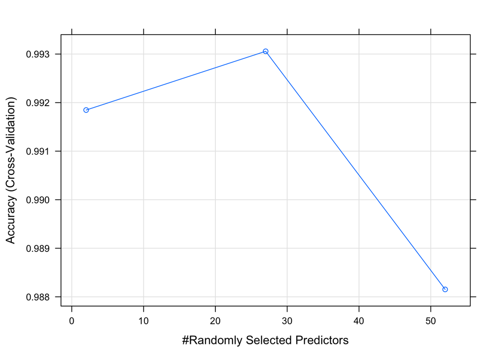

```r
#Plot the forest error and the confusion matrix
plot(forest)
```

```r
train_prediction_forest <- predict(forest, newdata = Test)
conf_matrix_forest <- confusionMatrix(table(Test[["classe"]],train_prediction_forest))
conf_matrix_forest[["overall"]][1]
```

```
##  Accuracy
## 0.9951568
```

```r
names(forest[["finalModel"]])
```

```
##  [1] "call"            "type"            "predicted"
##  [4] "err.rate"        "confusion"       "votes"
##  [7] "oob.times"       "classes"         "importance"
## [10] "importanceSD"    "localImportance" "proximity"
## [13] "ntree"           "mtry"            "forest"
## [16] "y"               "test"            "inbag"
## [19] "xNames"          "problemType"     "tuneValue"
## [22] "obsLevels"       "param"
```

```r
forest[["finalModel"]][["classes"]]
```

```
## [1] "A" "B" "C" "D" "E"
```

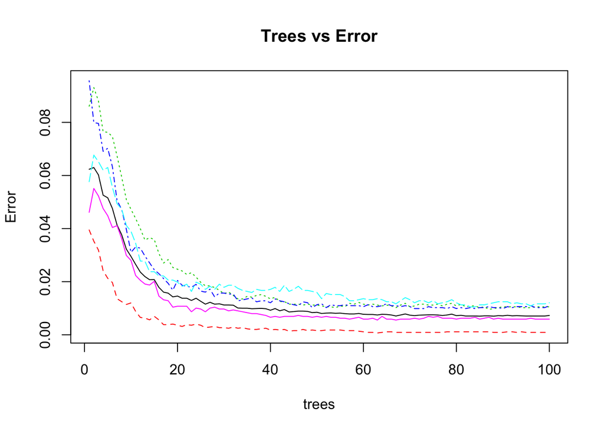

```r
plot(forest[["finalModel"]], main = "Trees vs Error")
```

### Testing Stage

This particular stage, this is where the algorithm will be put to the test for the quiz.

```r
Final_Prediction <- predict(forest, newdata = x_test_updated)
Final_Prediction
```

```
##  [1] B A B A A E D B A A B C B A E E A B B B
## Levels: A B C D E
```